# Challenge 06

Analyse der Matomo-HaNS-Daten

“Ein Hackathon-Variante zur Evaluation der Klickdaten des KI-Tools ‘HaNS’”

Autor:in

Sebastian Sauer

Veröffentlichungsdatum

3. Februar 2025

# 1 Setup

## 1.1 R-Pakete starten

```r
library(targets)
library(tidyverse)
library(ggokabeito)  # Farben
library(easystats)
library(gt)  # Tabellen in HTML
#library(ggfittext)
#library(scales)
library(visdat)
```

```r
theme_set(theme_minimal())
```

## 1.2 Daten importieren und inspizieren

### 1.2.1 Targets-Objekte laden

```r
tar_load(action_types, store = "challenge06")
tar_load(data_users_only, store = "challenge06")
tar_load(actions_per_visit, store = "challenge06")
# tar_load(time_minmax, store = "challenge06")
# tar_load(time_since_last_visit,store = "challenge06")
tar_load(numeric_id, store = "challenge06")
```

### 1.2.2 Dimension

Jede Zeile entspricht einem “Visit”.

### 1.2.3 Erster Blick

```r
data_users_only_head100 <-
data_users_only %>%
  select(1:100) %>%
  slice_head(n = 100)
```

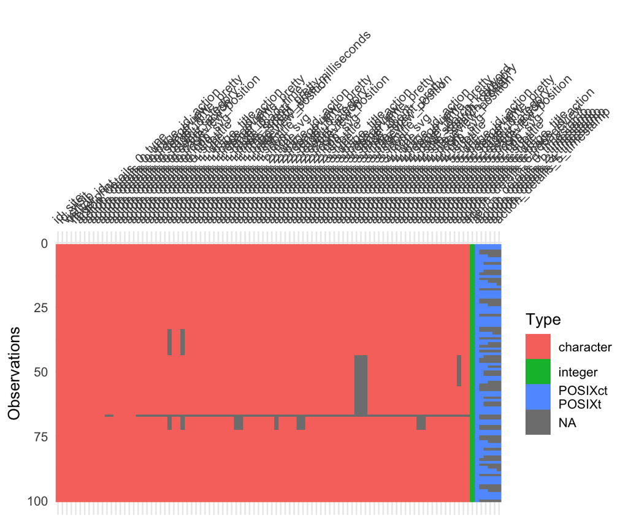

```r
data_users_only_head100 %>%
  visdat::vis_dat()
```

### 1.2.4 Namen (1-100)

```r
data_users_only_head100 %>%
  names()
##   [1] "file"
##   [2] "id_site"
##   [3] "id_visit"
##   [4] "visit_ip"
##   [5] "visitor_id"
##   [6] "fingerprint"
##   [7] "action_details_0_type"
##   [8] "action_details_0_url"
##   [9] "action_details_0_page_id_action"
##  [10] "action_details_0_idpageview"
##  [11] "action_details_0_server_time_pretty"
##  [12] "action_details_0_page_id"
##  [13] "action_details_0_event_category"
##  [14] "action_details_0_event_action"
##  [15] "action_details_0_pageview_position"
##  [16] "action_details_0_timestamp"
##  [17] "action_details_0_icon"
##  [18] "action_details_0_icon_svg"
##  [19] "action_details_0_title"
##  [20] "action_details_0_subtitle"
##  [21] "action_details_1_type"
##  [22] "action_details_1_url"
##  [23] "action_details_1_page_title"
##  [24] "action_details_1_page_id_action"
##  [25] "action_details_1_idpageview"
##  [26] "action_details_1_server_time_pretty"
##  [27] "action_details_1_page_id"
##  [28] "action_details_1_page_load_time"
##  [29] "action_details_1_time_spent"
##  [30] "action_details_1_time_spent_pretty"
##  [31] "action_details_1_page_load_time_milliseconds"
##  [32] "action_details_1_pageview_position"
##  [33] "action_details_1_title"
##  [34] "action_details_1_subtitle"
##  [35] "action_details_1_icon"
##  [36] "action_details_1_icon_svg"
##  [37] "action_details_1_timestamp"
##  [38] "action_details_2_type"
##  [39] "action_details_2_url"
##  [40] "action_details_2_page_id_action"
##  [41] "action_details_2_idpageview"
##  [42] "action_details_2_server_time_pretty"
##  [43] "action_details_2_page_id"
##  [44] "action_details_2_event_category"
##  [45] "action_details_2_event_action"
##  [46] "action_details_2_pageview_position"
##  [47] "action_details_2_timestamp"
##  [48] "action_details_2_icon"
##  [49] "action_details_2_icon_svg"
##  [50] "action_details_2_title"
##  [51] "action_details_2_subtitle"
##  [52] "action_details_3_type"
##  [53] "action_details_3_url"
##  [54] "action_details_3_page_title"
##  [55] "action_details_3_page_id_action"
##  [56] "action_details_3_idpageview"
##  [57] "action_details_3_server_time_pretty"
##  [58] "action_details_3_page_id"
##  [59] "action_details_3_time_spent"
##  [60] "action_details_3_time_spent_pretty"
##  [61] "action_details_3_pageview_position"
##  [62] "action_details_3_title"
##  [63] "action_details_3_subtitle"
##  [64] "action_details_3_icon"
##  [65] "action_details_3_icon_svg"
##  [66] "action_details_3_timestamp"
##  [67] "action_details_4_type"
##  [68] "action_details_4_url"
##  [69] "action_details_4_page_id_action"
##  [70] "action_details_4_idpageview"
##  [71] "action_details_4_server_time_pretty"
##  [72] "action_details_4_page_id"
##  [73] "action_details_4_site_search_keyword"
##  [74] "action_details_4_site_search_category"
##  [75] "action_details_4_site_search_count"
##  [76] "action_details_4_pageview_position"
##  [77] "action_details_4_icon"
##  [78] "action_details_4_icon_svg"
##  [79] "action_details_4_title"
##  [80] "action_details_4_subtitle"
##  [81] "action_details_4_timestamp"
##  [82] "action_details_5_type"
##  [83] "action_details_5_url"
##  [84] "action_details_5_page_id_action"
##  [85] "action_details_5_idpageview"
##  [86] "action_details_5_server_time_pretty"
##  [87] "action_details_5_page_id"
##  [88] "action_details_5_event_category"
##  [89] "action_details_5_event_action"
##  [90] "action_details_5_pageview_position"
##  [91] "action_details_5_timestamp"
##  [92] "action_details_5_icon"
##  [93] "action_details_5_icon_svg"
##  [94] "action_details_5_title"
##  [95] "action_details_5_subtitle"
##  [96] "action_details_6_type"
##  [97] "action_details_6_url"
##  [98] "action_details_6_page_title"
##  [99] "action_details_6_page_id_action"
## [100] "action_details_6_idpageview"
```

### 1.2.5 Werte der erst 100 Spalten

```r
data_users_only_head100 %>%
  glimpse()
## Rows: 100
## Columns: 100
## $ file                                         <int> 1, 1, 1, 1, 1, 1, 1, 1, 1…
## $ id_site                                      <chr> "1", "1", "1", "1", "1", …
## $ id_visit                                     <chr> "19", "18", "17", "14", "…
## $ visit_ip                                     <chr> "172.30.0.0", "172.30.0.0…
## $ visitor_id                                   <chr> "01357ce636fa78c2", "a0fe…
## $ fingerprint                                  <chr> "9ffcf86ca880ddaa", "4524…
## $ action_details_0_type                        <chr> "event", "action", "event…
## $ action_details_0_url                         <chr> "https://hans.th-nuernber…
## $ action_details_0_page_id_action              <chr> "17", "2", "17", "192", "…
## $ action_details_0_idpageview                  <chr> "1YNiVr", "DNNr9n", "Vfj7…
## $ action_details_0_server_time_pretty          <chr> "Mar 4, 2024 22:58:30", "…
## $ action_details_0_page_id                     <chr> "6509", "5632", "5621", "…
## $ action_details_0_event_category              <chr> "click_button", "", "clic…
## $ action_details_0_event_action                <chr> "Kanäle", "", "Kanäle", "…
## $ action_details_0_pageview_position           <chr> "", "1", "", "1", "1", "1…
## $ action_details_0_timestamp                   <dttm> 2024-03-04 22:58:30, 202…
## $ action_details_0_icon                        <chr> "plugins/Morpheus/images/…
## $ action_details_0_icon_svg                    <chr> "plugins/Morpheus/images/…
## $ action_details_0_title                       <chr> "Event", "HAnS", "Event",…
## $ action_details_0_subtitle                    <chr> "Category: \"\"click_butt…
## $ action_details_1_type                        <chr> "action", "event", "", ""…
## $ action_details_1_url                         <chr> "https://hans.th-nuernber…
## $ action_details_1_page_title                  <chr> "HAnS", "", "", "", "", "…
## $ action_details_1_page_id_action              <chr> "32", "3", "", "", "", ""…
## $ action_details_1_idpageview                  <chr> "HKiQ62", "DNNr9n", "", "…
## $ action_details_1_server_time_pretty          <chr> "Mar 4, 2024 23:16:59", "…
## $ action_details_1_page_id                     <chr> "6511", "5633", "", "", "…
## $ action_details_1_page_load_time              <chr> "0.94s", "", "", "", "", …
## $ action_details_1_time_spent                  <chr> "21", "", "", "", "", "",…
## $ action_details_1_time_spent_pretty           <chr> "21s", "", "", "", "", ""…
## $ action_details_1_page_load_time_milliseconds <chr> "940", "", "", "", "", ""…
## $ action_details_1_pageview_position           <chr> "1", "1", "", "", "2", "2…
## $ action_details_1_title                       <chr> "HAnS", "Event", "", "", …
## $ action_details_1_subtitle                    <chr> "https://hans.th-nuernber…
## $ action_details_1_icon                        <chr> "", "plugins/Morpheus/ima…
## $ action_details_1_icon_svg                    <chr> "plugins/Morpheus/images/…
## $ action_details_1_timestamp                   <dttm> 2024-03-04 23:16:59, 202…
## $ action_details_2_type                        <chr> "event", "action", "", ""…
## $ action_details_2_url                         <chr> "https://hans.th-nuernber…
## $ action_details_2_page_id_action              <chr> "33", "147", "", "", "147…
## $ action_details_2_idpageview                  <chr> "HKiQ62", "1wrpnl", "", "…
## $ action_details_2_server_time_pretty          <chr> "Mar 4, 2024 23:17:20", "…
## $ action_details_2_page_id                     <chr> "6512", "5634", "", "", "…
## $ action_details_2_event_category              <chr> "click_channelcard", "", …
## $ action_details_2_event_action                <chr> "ZELLKU", "", "", "", "",…
## $ action_details_2_pageview_position           <chr> "1", "2", "", "", "2", "2…
## $ action_details_2_timestamp                   <dttm> 2024-03-04 23:17:20, 202…
## $ action_details_2_icon                        <chr> "plugins/Morpheus/images/…
## $ action_details_2_icon_svg                    <chr> "plugins/Morpheus/images/…
## $ action_details_2_title                       <chr> "Event", "HAnS", "", "", …
## $ action_details_2_subtitle                    <chr> "Category: \"\"click_chan…
## $ action_details_3_type                        <chr> "action", "search", "", "…
## $ action_details_3_url                         <chr> "https://hans.th-nuernber…
## $ action_details_3_page_title                  <chr> "HAnS", "", "", "", "", "…
## $ action_details_3_page_id_action              <chr> "36", "", "", "", "", "95…
## $ action_details_3_idpageview                  <chr> "E8FkLA", "1wrpnl", "", "…
## $ action_details_3_server_time_pretty          <chr> "Mar 4, 2024 23:17:20", "…
## $ action_details_3_page_id                     <chr> "6513", "5635", "", "", "…
## $ action_details_3_time_spent                  <chr> "10", "", "", "", "", "11…
## $ action_details_3_time_spent_pretty           <chr> "10s", "", "", "", "", "1…
## $ action_details_3_pageview_position           <chr> "2", "2", "", "", "", "4"…
## $ action_details_3_title                       <chr> "HAnS", "Site Search", ""…
## $ action_details_3_subtitle                    <chr> "https://hans.th-nuernber…
## $ action_details_3_icon                        <chr> "", "plugins/Morpheus/ima…
## $ action_details_3_icon_svg                    <chr> "plugins/Morpheus/images/…
## $ action_details_3_timestamp                   <dttm> 2024-03-04 23:17:20, 202…
## $ action_details_4_type                        <chr> "search", "event", "", ""…
## $ action_details_4_url                         <chr> "", "https://hans.th-nuer…
## $ action_details_4_page_id_action              <chr> "", "246", "", "", "", "1…
## $ action_details_4_idpageview                  <chr> "E8FkLA", "1wrpnl", "", "…
## $ action_details_4_server_time_pretty          <chr> "Mar 4, 2024 23:17:20", "…
## $ action_details_4_page_id                     <chr> "6514", "5637", "", "", "…
## $ action_details_4_site_search_keyword         <chr> "ZELLKU", "", "", "", "",…
## $ action_details_4_site_search_category        <chr> "", "", "", "", "", "", "…
## $ action_details_4_site_search_count           <chr> "0", "", "", "", "", "", …
## $ action_details_4_pageview_position           <chr> "2", "3", "", "", "", "5"…
## $ action_details_4_icon                        <chr> "plugins/Morpheus/images/…
## $ action_details_4_icon_svg                    <chr> "plugins/Morpheus/images/…
## $ action_details_4_title                       <chr> "Site Search", "Event", "…
## $ action_details_4_subtitle                    <chr> "ZELLKU", "Category: \"\"…
## $ action_details_4_timestamp                   <dttm> 2024-03-04 23:17:20, 202…
## $ action_details_5_type                        <chr> "event", "action", "", ""…
## $ action_details_5_url                         <chr> "https://hans.th-nuernber…
## $ action_details_5_page_id_action              <chr> "38", "95", "", "", "", "…
## $ action_details_5_idpageview                  <chr> "E8FkLA", "wZEbOS", "", "…
## $ action_details_5_server_time_pretty          <chr> "Mar 4, 2024 23:17:30", "…
## $ action_details_5_page_id                     <chr> "6515", "5638", "", "", "…
## $ action_details_5_event_category              <chr> "click_videocard", "", ""…
## $ action_details_5_event_action                <chr> "2-ELISA", "", "", "", ""…
## $ action_details_5_pageview_position           <chr> "3", "4", "", "", "", "5"…
## $ action_details_5_timestamp                   <dttm> 2024-03-04 23:17:30, 202…
## $ action_details_5_icon                        <chr> "plugins/Morpheus/images/…
## $ action_details_5_icon_svg                    <chr> "plugins/Morpheus/images/…
## $ action_details_5_title                       <chr> "Event", "HAnS", "", "", …
## $ action_details_5_subtitle                    <chr> "Category: \"\"click_vide…
## $ action_details_6_type                        <chr> "action", "event", "", ""…
## $ action_details_6_url                         <chr> "https://hans.th-nuernber…
## $ action_details_6_page_title                  <chr> "HAnS", "", "", "", "", "…
## $ action_details_6_page_id_action              <chr> "274", "247", "", "", "",…
## $ action_details_6_idpageview                  <chr> "DXTmIN", "wZEbOS", "", "…
```

### 1.2.6 Datensatz im Lang-Format, Zeilen 1-100

```r
numeric_id %>%
  slice(1:100) |>
  gt()
```

| id_visit | name | value | action_count |
| --- | --- | --- | --- |
| 19 | action_details_0_type | event | 0 |
| 19 | action_details_0_url | https://hans.th-nuernberg.de/?evalId=none&role=developer | 0 |
| 19 | action_details_0_page_id_action | 17 | 0 |
| 19 | action_details_0_idpageview | 1YNiVr | 0 |
| 19 | action_details_0_server_time_pretty | Mar 4, 2024 22:58:30 | 0 |
| 19 | action_details_0_page_id | 6509 | 0 |
| 19 | action_details_0_event_category | click_button | 0 |
| 19 | action_details_0_event_action | Kanäle | 0 |
| 19 | action_details_0_timestamp | 2024-03-04 22:58:30 | 0 |
| 19 | action_details_0_icon | plugins/Morpheus/images/event.png | 0 |
| 19 | action_details_0_icon_svg | plugins/Morpheus/images/event.svg | 0 |
| 19 | action_details_0_title | Event | 0 |
| 19 | action_details_0_subtitle | Category: ""click_button', Action: ""Kanäle"" | 0 |
| 19 | action_details_1_type | action | 1 |
| 19 | action_details_1_url | https://hans.th-nuernberg.de/channels?evalId=none&role=developer | 1 |
| 19 | action_details_1_page_title | HAnS | 1 |
| 19 | action_details_1_page_id_action | 32 | 1 |
| 19 | action_details_1_idpageview | HKiQ62 | 1 |
| 19 | action_details_1_server_time_pretty | Mar 4, 2024 23:16:59 | 1 |
| 19 | action_details_1_page_id | 6511 | 1 |
| 19 | action_details_1_page_load_time | 0.94s | 1 |
| 19 | action_details_1_time_spent | 21 | 1 |
| 19 | action_details_1_time_spent_pretty | 21s | 1 |
| 19 | action_details_1_page_load_time_milliseconds | 940 | 1 |
| 19 | action_details_1_pageview_position | 1 | 1 |
| 19 | action_details_1_title | HAnS | 1 |
| 19 | action_details_1_subtitle | https://hans.th-nuernberg.de/channels?evalId=none&role=developer | 1 |
| 19 | action_details_1_icon_svg | plugins/Morpheus/images/action.svg | 1 |
| 19 | action_details_1_timestamp | 2024-03-04 23:16:59 | 1 |
| 19 | action_details_2_type | event | 2 |

[output cut: 70 more lines]

## 1.3 Zeitraum

### 1.3.1 Beginn/Ende der Daten

```r
# time_minmax |>
#   summarise(time_min = min(time_min),
#             time_max = max(time_max)) |>
#   gt()
```

### 1.3.2 Days since last visit

```r
# time_since_last_visit <-
# time_since_last_visit |>
#   mutate(days_since_last_visit = as.numeric(days_since_last_visit))
#
# time_since_last_visit |>
#   datawizard::describe_distribution(days_since_last_visit) |>
#   knitr::kable()
#
# time_since_last_visit |>
#   ggplot(aes(x = days_since_last_visit)) +
#   geom_density()
```

## 1.4 Anzahl Visits

```r
glimpse(action_types)
## Rows: 2,585,360
## Columns: 4
## $ id_visit     <chr> "19", "19", "19", "19", "19", "19", "19", "19", "19", "19…
## $ type         <chr> "type", "url", "page", "idpageview", "server", "page", "e…
## $ value        <chr> "event", "https://hans.th-nuernberg.de/?evalId=none&role=…
## $ action_count <int> 0, 0, 0, 0, 0, 0, 0, 0, 0, 0, 0, 0, 0, 1, 1, 1, 1, 1, 1, …
```

```r
action_types$id_visit |> unique() |> length()
## [1] 1771
```

## 1.5 Anzahl der Aktionen pro Visit

`action_count` fasst die Nummer der Aktion innerhalb eines bestimmten Visits. `type` gibt den Typ der protokollierten Aktion an, z.B. ob es ein Timestamp war.

### 1.5.1 Mit allen Daten (den 499er-Daten)

```r
actions_per_visit |>
  describe_distribution(nr_max) |>
  gt() |>
  fmt_number(columns = where(is.numeric),
             decimals = 2)
```

| Variable | Mean | SD | IQR | Min | Max | Skewness | Kurtosis | n | n_Missing |
| --- | --- | --- | --- | --- | --- | --- | --- | --- | --- |
| nr_max | 85.71 | 163.16 | 65.00 | 0.00 | 499.00 | 1.89 | 1.96 | 1,771.00 | 0.00 |

`nr_max` gibt den Maximalwert von `nr` zurück, sagt also, wie viele Aktionen maximal von einem Visitor ausgeführt wurden.

Betrachtet man die Anzahl der Aktionen pro Visitor näher, so fällt auf, dass der Maximalwert (499) sehr häufig vorkommt:

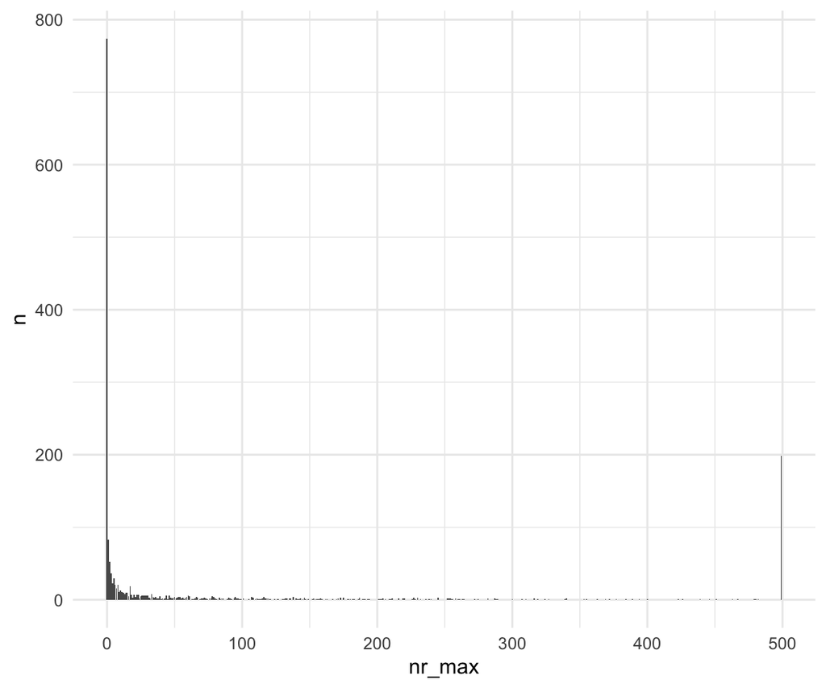

```r
actions_per_visit |>
  count(nr_max) |>
  ggplot(aes(x = nr_max, y = n)) +
  geom_col()
```

Hier noch in einer anderen Darstellung:

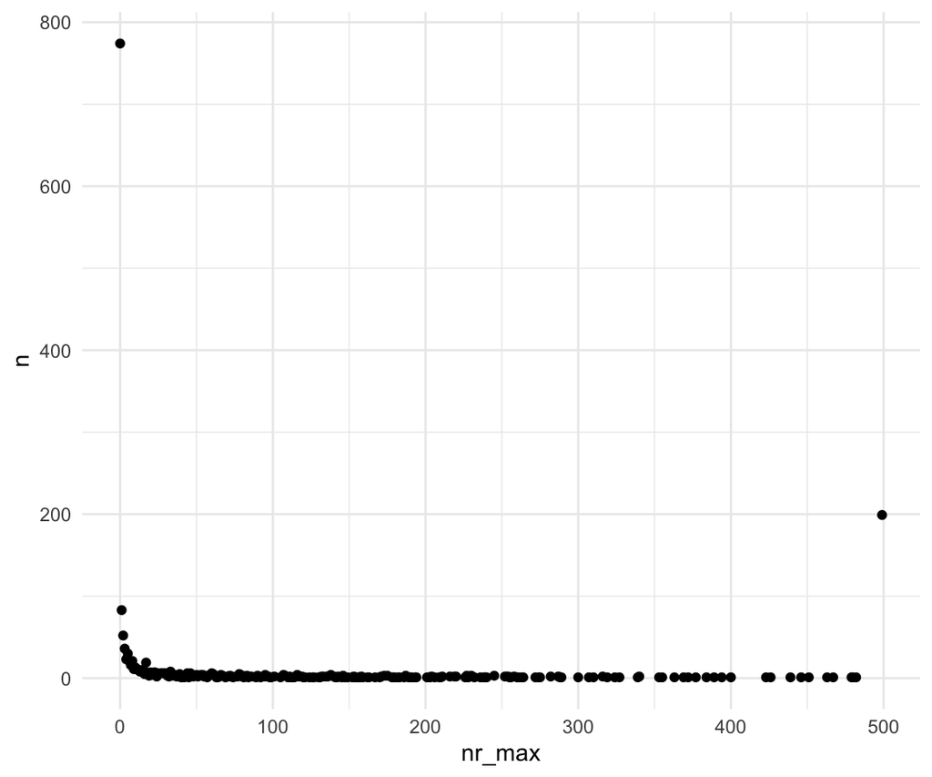

```r
actions_per_visit |>
  count(nr_max) |>
  ggplot(aes(x = nr_max, y = n)) +
  geom_point()
```

Der Maximalwert ist einfach auffällig häufig:

```r
actions_per_visit |>
  count(nr_max == 499) |>
  gt()
```

| nr_max == 499 | n |
| --- | --- |
| FALSE | 1572 |
| TRUE | 199 |

Es erscheint plausibel, dass der Maximalwert alle “gekappten” (zensierten, abgeschnittenen) Werte fasst, also viele Werte, die eigentlich größer wären (aber dann zensiert wurden).

### 1.5.2 Nur Visitors, für die weniger als 500 Aktionen protokolliert sind

```r
actions_per_visit2 <-
actions_per_visit |>
  filter(nr_max != 499)

actions_per_visit2 |>
  describe_distribution(nr_max) |>
  gt() |>
  fmt_number(columns = where(is.numeric),
             decimals = 2)
```

| Variable | Mean | SD | IQR | Min | Max | Skewness | Kurtosis | n | n_Missing |
| --- | --- | --- | --- | --- | --- | --- | --- | --- | --- |
| nr_max | 33.40 | 74.96 | 22.00 | 0.00 | 482.00 | 3.11 | 10.55 | 1,572.00 | 0.00 |

## 1.6 Verteilung

### 1.6.1 Mit den 499er-Daten

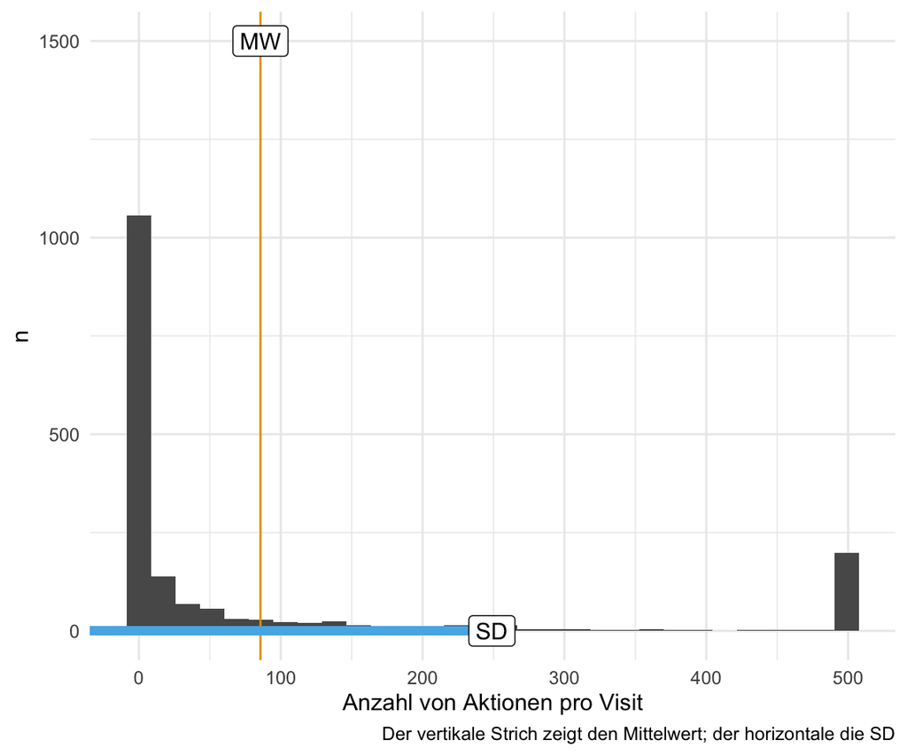

```r
actions_per_visit_avg = mean(actions_per_visit$nr_max)
actions_per_visit_sd = sd(actions_per_visit$nr_max)

actions_per_visit |>
  ggplot() +
  geom_histogram(aes(x = nr_max)) +
  labs(x = "Anzahl von Aktionen pro Visit",
       y = "n",
       caption = "Der vertikale Strich zeigt den Mittelwert; der horizontale die SD") +
  theme_minimal() +
  geom_vline(xintercept = actions_per_visit_avg,
             color = palette_okabe_ito()[1]) +
  geom_segment(x = actions_per_visit_avg-actions_per_visit_sd,
               y = 0,
               xend = actions_per_visit_avg + actions_per_visit_sd,
               yend = 0,
               color = palette_okabe_ito()[2],
               size = 2) +
  annotate("label", x = actions_per_visit_avg, y = 1500, label = "MW") +
  annotate("label", x = actions_per_visit_avg + actions_per_visit_sd, y = 0, label = "SD")
```

```r
  #geom_label(aes(x = actions_per_visit_avg), y = 1, label = "Mean")
```

- Mittelwert der Aktionen pro Visit: 85.71.
- SD der Aktionen pro Visit: 163.16.

### 1.6.2 Ohne 499er-Daten

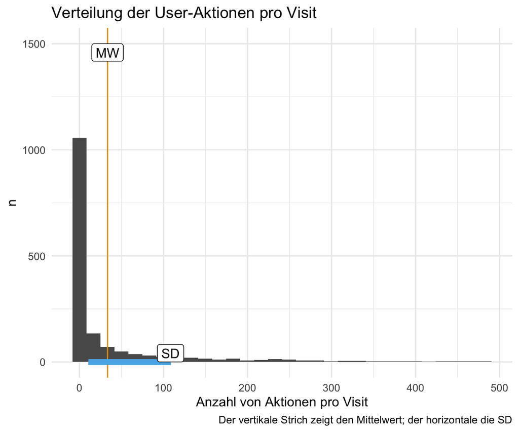

```r
actions_per_visit_avg2 = mean(actions_per_visit2$nr_max)
actions_per_visit_sd2 = sd(actions_per_visit2$nr_max)

actions_per_visit2 |>
  ggplot() +
  geom_histogram(aes(x = nr_max)) +
  labs(x = "Anzahl von Aktionen pro Visit",
       y = "n",
       title = "Verteilung der User-Aktionen pro Visit",
       caption = "Der vertikale Strich zeigt den Mittelwert; der horizontale die SD") +
  theme_minimal() +
  geom_vline(xintercept = actions_per_visit_avg2,
             color = palette_okabe_ito()[1]) +
  geom_segment(x = actions_per_visit_avg-actions_per_visit_sd2,
               y = 0,
               xend = actions_per_visit_avg2 + actions_per_visit_sd2,
               yend = 0,
               color = palette_okabe_ito()[2],
               size = 2) +
  annotate("label", x = actions_per_visit_avg2, y = 1500, label = "MW", vjust = "top") +
  annotate("label", x = actions_per_visit_avg2 + actions_per_visit_sd2, y = 0, label = "SD", vjust = "bottom")
```

```r
  #geom_label(aes(x = actions_per_visit_avg), y = 1, label = "Mean")
```

- Mittelwert der Aktionen pro Visit: 33.4.
- SD der Aktionen pro Visit: 74.96.